# 4DN DamID - Ki67 project - pA-DamID vs ChIP-seq

Tom van Schaik

2022-06-01

### Project

Mapping of Ki67 interactions with the genome and comparison with lamina interactions.

### Introduction

I generated lots of Ki-67 maps with pA-DamID. I would also argue that this method is especially suited for these purposes, given the strong normalization control, in situ methylation, etc. However, I never really showed this.

NQ now helped me to generate Ki-67 ChIP-seq data. We did this in the HCT116 cells with AID-tagged Ki-67, with and without auxin addition. I have generated the same data with pA-DamID. Time to compare.

### Method

Various comparisons of the data.

### Set-up

Set the parameters and list the data.

```r
# Load dependencies - without warnings / messages
library(tidyverse)
library(GenomicRanges)
library(rtracklayer)
library(ggplot2)
library(RColorBrewer)
library(GGally)
library(corrr)
library(caTools)
library(colorspace)
library(ggrastr)

# Prepare output
output_dir <- "ts220503_3_hct116_ki67aid_padamid_vs_chipseq"
dir.create(output_dir, showWarnings = FALSE)


# Load input
chromosomes <- c(paste0("chr", 1:22), "chrX")


input_dir <- "ts220503_1_data_gathering"

bin_size <- readRDS(file.path(input_dir, "bin_size.rds"))
centromeres <- readRDS(file.path(input_dir, "centromeres.rds"))

colors_set1 <- readRDS(file.path(input_dir, "colors_set1.rds"))
colors_set2 <- readRDS(file.path(input_dir, "colors_set2.rds"))
colors_set3 <- readRDS(file.path(input_dir, "colors_set3.rds"))

# tib_padamid_replicates <- readRDS(file.path(input_dir,
#                                             "tib_padamid_replicates.rds"))
# tib_padamid_combined <- readRDS(file.path(input_dir,
#                                           "tib_padamid_combined.rds"))
#
# gr_padamid_replicates <- readRDS(file.path(input_dir,
#                                            "gr_padamid_replicates.rds"))
gr_padamid_combined <- readRDS(file.path(input_dir,
                                         "gr_padamid_combined.rds"))
#
# tib_hmm_replicates <- readRDS(file.path(input_dir, "tib_hmm_replicates.rds"))
# tib_hmm_combined <- readRDS(file.path(input_dir, "tib_hmm_combined.rds"))

padamid_metadata_replicates <- readRDS(file.path(input_dir,
                                                 "padamid_metadata_replicates.rds"))
# padamid_metadata_combined <- readRDS(file.path(input_dir,
#                                                "padamid_metadata_combined.rds"))



# Prepare seqnames
chrom_sizes <- tibble(seqnames = seqlevels(gr_padamid_combined),
                      length = seqlengths(gr_padamid_combined)) %>%
  arrange(-length)


# # Scale pA-DamID scores?
# tib_padamid_combined <- tib_padamid_combined %>%
#   mutate_at(4:ncol(.), function(x) scale(x)[, 1]) %>%
#   filter(seqnames != "chrY")
```

```r
library(knitr)
opts_chunk$set(fig.width = 10, fig.height = 4, cache = T,
               dev=c('png', 'pdf'), fig.path = file.path(output_dir, "figures/"))
pdf.options(useDingbats = FALSE)
```

```r
# From Fede:
# ggpairs custom functions
corColor <- function(data, mapping, color = I("black"), sizeRange = c(1, 3), ...) {

  x   <- eval_data_col(data, mapping$x)
  y   <- eval_data_col(data, mapping$y)
  r   <- cor(x, y)
  rt  <- format(r, digits = 3)
  tt  <- as.character(rt)
  cex <- max(sizeRange)

  # helper function to calculate a useable size
  percent_of_range <- function(percent, range) {
    percent * diff(range) + min(range, na.rm = TRUE)
  }

  # plot correlation coefficient
  p <- ggally_text(label = tt, mapping = aes(), xP = 0.5, yP = 0.5,
                   # size = I(percent_of_range(cex * abs(r), sizeRange)),
                   size = 6,
                   color = color, ...) +
    theme(panel.grid.minor=element_blank(),
          panel.grid.major=element_blank())

  corColors <- RColorBrewer::brewer.pal(n = 7, name = "RdYlBu")[2:6]

  if (r <= boundaries[1]) {
    corCol <- corColors[1]
  } else if (r <= boundaries[2]) {
    corCol <- corColors[2]
  } else if (r < boundaries[3]) {
    corCol <- corColors[3]
  } else if (r < boundaries[4]) {
    corCol <- corColors[4]
  } else {
    corCol <- corColors[5]
  }

  p <- p +
    theme(panel.background = element_rect(fill = corCol))

  return(p)
}

customScatter <- function (data, mapping)
{
    p <- ggplot(data = data, mapping) +
      geom_bin2d(bins = 100) +
      geom_smooth(method = "lm", se = T, col = "red") +
      scale_fill_gradient(low = "lightgrey", high = "black", name = "Count") +
      theme_bw()

    p
}

PlotScatter <- function(tib, n1, n2, color_by = NULL, identity = F, smooth = 1) {
  # Get tibble
  tib <- tib %>%
    dplyr::select(seqnames, matches(n1), matches(n2)) %>%
    rename_all(~ c("seqnames", "n1", "n2"))

  if (smooth > 1) {
    tib <- tib %>%
      group_by(seqnames) %>%
      mutate(n1 = runmean(n1, k = smooth),
             n2 = runmean(n2, k = smooth))
  }

  # Prepare color
  if (! is.null(color_by)) {
    tib <- tib %>%
      add_column(color = color_by) %>%
      drop_na()
    alpha = 1
    limits_color <- quantile(tib$color, c(0.001, 0.999), na.rm = T)
    tib$color[tib$color < limits_color[1]] <- limits_color[1]
    tib$color[tib$color > limits_color[2]] <- limits_color[2]
  } else {
    tib <- tib %>% drop_na()
    tib$color = "1"
    alpha = 0.02
  }

  # Plot
  xlimits <- quantile(tib$n1, c(0.001, 0.999), na.rm = T) * 1.4
  ylimits <- quantile(tib$n2, c(0.001, 0.999), na.rm = T) * 1.4

  plt <- tib %>%
    arrange(sample(1:nrow(.), size = nrow(.), replace = F)) %>%
    ggplot(aes(x = n1, y = n2, color = color)) +
    geom_point(size = 0.5, alpha = alpha) +
    geom_hline(yintercept = 0, col = "black", linetype = "dashed") +
    geom_vline(xintercept = 0, col = "black", linetype = "dashed") +
    xlab(n1) +
    ylab(n2) +
    ggtitle(paste0("Spearman: ",
                   round(cor(tib$n1, tib$n2, use = "complete.obs",
                             method = "spearman"), 2))) +
    coord_cartesian(xlim = xlimits, ylim = ylimits) +
    theme_bw() +
    theme(aspect.ratio = 1)

  # Prepare color
  if (! is.null(color_by)) {
    plt <- plt +
      scale_color_gradient2(low = "blue", mid = "grey", high = "red",
                            midpoint = 0)
  } else {
    plt <- plt +
      scale_color_manual(values = "black", guide = F)
  }
  if (identity) plt <- plt + geom_abline(slope = 1, intercept = 0, col = "red", linetype = "dashed")

  plot(plt)

}

# Simple data track plotting with various options and "manual" control of
# colors
PlotDataTracksLight <- function(input_tib, exp_names, centromeres,
                                color_groups, plot_chr = "chr1",
                                plot_start = 1, plot_end = 500e6,
                                smooth = 1, color_list = NULL,
                                fix_yaxis = F, aspect_ratio = NULL,
                                lighten_negative = T, raster = T,
                                ylimits = NULL) {

  # Get the scores for the samples
  tib_plot <- input_tib %>%
    dplyr::select(seqnames, start, end,
                  all_of(exp_names))

  if (smooth > 1) {
    tib_plot <- tib_plot %>%
      mutate_at(vars(contains("_")),
                runmean, k = smooth)
  }

  # Filter for plotting window
  tib_plot <- tib_plot %>%
    filter(seqnames == plot_chr,
           start >= plot_start,
           end <= plot_end)

  # Gather
  tib_gather <- tib_plot %>%
    gather(key, value, -seqnames, -start, -end) %>%
    mutate(key = factor(key, levels = exp_names),
           fill_column = color_groups[match(key, names(color_groups))],
           fill_column = factor(fill_column, levels = unique(color_groups)))

  # If desired, make negative values a lighter shade to improve visualization
  if (lighten_negative) {
    tib_gather <- tib_gather %>%
      mutate(fill_column = interaction(fill_column,
                                       value < 0))
  }


  # Centromeres
  centromeres.plt <- as_tibble(centromeres) %>%
    filter(seqnames == plot_chr) %>%
    gather(key_centromeres, value, start, end)

  # Plot
  if (is.null(ylimits)) {
    ylimits <- quantile(tib_gather$value, c(0.001, 0.999), na.rm = T)
  }

  fill_column <- NULL

  plt <- tib_gather %>%
    ggplot(aes(fill = fill_column))


  # Set all counts tracks to the same limits
  if (raster) {
    plt <- plt +
      rasterize(geom_rect(aes(xmin = start / 1e6, xmax = end / 1e6,
                              ymin = 0, ymax = value)),
                dpi = 300)
  } else {
    plt <- plt +
      geom_rect(aes(xmin = start / 1e6, xmax = end / 1e6,
                    ymin = 0, ymax = value))
  }

  plt <- plt +
    geom_hline(yintercept = 0, size = 0.5) +
    geom_line(data = centromeres.plt,
              aes(x = value / 1e6, y = 0),
              color = "black", size = 2) +
    facet_grid(key ~ ., scales = "free_y") +
    xlab(paste0(plot_chr, " (Mb)")) +
    ylab("Score") +
    scale_x_continuous(expand = c(0, 0)) +
    scale_y_continuous(expand = c(0.025, 0.025)) +
    theme_classic()
```

```r
  if (! is.null(color_list)) {

    if (lighten_negative) {
      color_list <- c(color_list,
                      lighten(color_list, amount = 0.5))
    }

    colors <- levels(tib_gather$fill_column)

    color_list <- color_list[1:length(colors)]
    names(color_list) <- colors
    #colors <- recode(colors, !!!color_list)

    plt <- plt +
      scale_fill_manual(values = color_list, guide = "none")
  } else {
    plt <- plt +
      scale_fill_brewer(palette = "Set1", guide = "none")
  }

  if (fix_yaxis) {
    plt <- plt +
      coord_cartesian(xlim = c(max(c(plot_start,
                                     min(tib_gather$start))) / 1e6,
                               min(c(plot_end,
                                     max(tib_gather$end))) / 1e6),
                      ylim = ylimits)
  } else {
    plt <- plt +
      coord_cartesian(xlim = c(max(c(plot_start,
                                     min(tib_gather$start))) / 1e6,
                               min(c(plot_end,
                                     max(tib_gather$end))) / 1e6))
  }

  if (! is.null(aspect_ratio)) {
    plt <- plt +
      theme(aspect.ratio = aspect_ratio)
  }

  plot(plt)

}

PlotScatterBinned <- function(tib, n1, n2, color_by = NULL, identity = F,
                              n_min = 10, ylimits_col = c(-2.4, 2.4),
                              count_range = c(0, 400), smooth = 1,
                              remove_outliers = F) {
  # Get tibble
  tib_process <- tib %>%
    dplyr::select(seqnames, all_of(n1), all_of(n2)) %>%
    rename_all(~ c("seqnames", "n1", "n2"))

  # Calculate pearson correlation without any smoothing
  tib_cor <- round(cor(tib_process$n1, tib_process$n2, use = "complete.obs",
                       method = "pearson"), 2)

  if (smooth > 1) {
    tib_process <- tib_process %>%
      group_by(seqnames) %>%
      mutate(n1 = runmean(n1, k = smooth),
             n2 = runmean(n2, k = smooth))
  }


  if (! is.null(color_by)) {
    tib_process <- tib_process %>%
      add_column(color = color_by)
  }

  tib_process <- tib_process %>%
    drop_na()

  # Change color range
  if (! is.null(color_by)) {
    limits_color <- quantile(tib_process$color, c(0.001, 0.999), na.rm = T)
    tib_process$color[tib_process$color < limits_color[1]] <- limits_color[1]
    tib_process$color[tib_process$color > limits_color[2]] <- limits_color[2]
  }

  # Replace outliers
  if (remove_outliers) {
    tib_process <- tib_process %>%
      mutate(n1 = case_when(n1 > quantile(n1, 0.999) ~ quantile(n1, 0.999),
                            n1 < quantile(n1, 0.001) ~ quantile(n1, 0.001),
                            T ~ n1),
             n2 = case_when(n2 > quantile(n2, 0.999) ~ quantile(n2, 0.999),
                            n2 < quantile(n2, 0.001) ~ quantile(n2, 0.001),
                            T ~ n2))
  }

  # Metrics
  n1_min = min(tib_process$n1) - 0.001
  n1_max = max(tib_process$n1) + 0.001
  n1_binsize <- (n1_max - n1_min) / 49

  n2_min = min(tib_process$n2) - 0.001
  n2_max = max(tib_process$n2) + 0.001
  n2_binsize <- (n2_max - n2_min) / 49

  tib_summary <- tib_process %>%
    mutate(n1_cut = cut(n1,
                        seq(n1_min, n1_max, length.out = 50)),
           n2_cut = cut(n2,
                        seq(n2_min, n2_max, length.out = 50))) %>%
    mutate(n1_bin = as.numeric(as.factor(n1_cut)),
           n2_bin = as.numeric(as.factor(n2_cut))) %>%
    mutate(n1_bin = n1_min - n1_binsize/2 + n1_bin * n1_binsize,
           n2_bin = n2_min - n2_binsize/2 + n2_bin * n2_binsize) %>%
    group_by(n1_bin, n2_bin)

  # Plot
  if (! is.null(color_by)) {
    tib_summary <- tib_summary %>%
    dplyr::summarise(n = n(),
                     mark = mean(color)) %>%
    ungroup() %>%
    filter(n >= n_min)

    plt <- tib_summary %>%
      ggplot(aes(x = n1_bin, y = n2_bin)) +
      geom_tile(aes(fill = mark)) +
      scale_fill_gradient2(low = "blue", mid = "grey", high = "red",
                           midpoint = 0, limits = ylimits_col,
                           na.value = "green")
  } else {
    tib_summary <- tib_summary %>%
    dplyr::summarise(n = n()) %>%
    ungroup() %>%
    filter(n >= n_min)

    plt <- tib_summary %>%
      ggplot(aes(x = n1_bin, y = n2_bin)) +
      geom_tile(aes(fill = n)) +
      scale_fill_gradient(low = "grey98", high = "black", name = "Count",
                          limits = count_range, na.value = "green")
  }

  plt <- plt +
    geom_hline(yintercept = 0, linetype = "dashed", col = "black") +
    geom_vline(xintercept = 0, linetype = "dashed", col = "black") +
    xlab(n1) +
    ylab(n2) +
    ggtitle(paste0("Pearson: ", tib_cor)) +
    theme_bw() +
    theme(aspect.ratio = 1)

  if (identity) plt <- plt + geom_abline(slope = 1, intercept = 0,
                                         col = "black", linetype = "dashed")

  plot(plt)

}

PlotDataTracksLightFaceted <- function(input_tib, exp_names, centromeres,
                                       color_groups, facet_groups,
                                       plot_chr = "chr1",
                                       plot_start = 1, plot_end = 500e6,
                                       smooth = 1, color_list = NULL,
                                       fix_yaxis = F) {

  # Exp names is a vector of sample names
  exp_search <- paste(exp_names, collapse = "|")

  # Get the scores for the samples
  tib_plot <- input_tib %>%
    dplyr::select(seqnames, start, end,
                  matches(exp_search))

  if (smooth > 1) {
    tib_plot <- tib_plot %>%
      mutate_at(vars(contains("_")),
                runmean, k = smooth)
  }

  # Filter for plotting window
  tib_plot <- tib_plot %>%
    filter(seqnames == plot_chr,
           start >= plot_start,
           end <= plot_end)

  # Gather
  tib_gather <- tib_plot %>%
    gather(key, value, -seqnames, -start, -end) %>%
    mutate(key = factor(key, levels = exp_names),
           fill_column = color_groups[match(key, names(color_groups))],
           fill_column = factor(fill_column, levels = unique(color_groups)),
           facet_column = facet_groups[match(key, names(facet_groups))],
           facet_column = factor(facet_column, levels = unique(facet_groups)))
```

```r
  # Centromeres
  centromeres.plt <- as_tibble(centromeres) %>%
    filter(seqnames == plot_chr) %>%
    gather(key_centromeres, value, start, end)

  # Plot
  ylimits <- quantile(tib_gather$value, c(0.001, 0.999), na.rm = T)
  fill_column <- NULL

  plt <- tib_gather %>%
    ggplot(aes(fill = fill_column))


  # Set all counts tracks to the same limits
  plt <- plt +
    #geom_rect(aes(xmin = start / 1e6, xmax = end / 1e6,
    #              ymin = 0, ymax = value)) +
    geom_line(aes(x = (start+end)/2e6, y = value,
                  col = fill_column)) +
    geom_line(data = centromeres.plt,
              aes(x = value / 1e6, y = 0),
              color = "black", size = 2) +
    geom_hline(yintercept = 0, size = 0.5) +
    facet_grid(facet_column ~ ., scales = "free_y") +
    xlab(paste0(plot_chr, " (Mb)")) +
    ylab("Score") +
    scale_x_continuous(expand = c(0, 0)) +
    scale_y_continuous(expand = c(0.025, 0.025)) +
    theme_classic()

  if (! is.null(color_list)) {
    colors <- levels(tib_gather$fill_column)

    color_list <- color_list[1:length(colors)]
    names(color_list) <- colors
    #colors <- recode(colors, !!!color_list)

    plt <- plt +
      scale_fill_manual(values = color_list, guide = F) +
      scale_color_manual(values = color_list, guide = F)
  } else {
    plt <- plt +
      scale_fill_brewer(palette = "Set1", guide = F) +
      scale_color_brewer(palette = "Set1", guide = F)
  }

  if (fix_yaxis) {
    plt <- plt +
      coord_cartesian(xlim = c(max(c(plot_start,
                                     min(tib_gather$start))) / 1e6,
                               min(c(plot_end,
                                     max(tib_gather$end))) / 1e6),
                      ylim = ylimits)
  } else {
    plt <- plt +
      coord_cartesian(xlim = c(max(c(plot_start,
                                     min(tib_gather$start))) / 1e6,
                               min(c(plot_end,
                                     max(tib_gather$end))) / 1e6))
  }

  plot(plt)

}

# Function
ExportBWFromTibble <- function(tib, bigwig_dir, column = "diff", name = NULL) {

  # Set name as column
  if (is.null(name)) name <- column

  # Get GRanges from Tibble
  gr <- tib %>%
    dplyr::select(1:3, all_of(column)) %>%
    drop_na() %>%
    dplyr::rename_at(4, ~ "score") %>%
    as(., "GRanges")

  # Exception: LADs and SPIN states
  if (grepl("LAD", column)) {
    gr$score <- ifelse(gr$score == "LAD", 1, 0)
  }

  if (grepl("SPIN", column)) {
    return(NULL)
  }

  # Add chromosome information
  seqlengths(gr) <- chrom_sizes$length[match(seqlevels(gr),
                                             chrom_sizes$seqnames)]

  # Write bigwig
  export.bw(object = gr,
            con = file.path(bigwig_dir, paste0(name, ".bw")))

}

BWsFromTibble <- function(tib) {
  invisible(lapply(names(tib)[4:ncol(tib)],
                   function(sample) {
                     ExportBWFromTibble(tib,
                                        bigwig_dir = bigwig_dir,
                                        column = sample)
                   }
  ))
}

AddSuffix <- function(x, suffix, col_start = 4) {
  x %>% rename_at(col_start:ncol(.),
                  function(a) paste0(a, suffix))
}

# Prepare bigwigs - normalized
bigwig_dir <- file.path(output_dir, "bigwig")
dir.create(bigwig_dir, showWarnings = F)
```

### 1. Load counts

Instead of starting with the normalized values, I will start with the cpm normalized counts. This means that I can also compare the counts between time points (as will become clear later in this document).

First pA-DamID.

```r
# First, get the metadata - do this mostly manually
counts_dir <- file.path("results/tracks/counts/",
                        paste0("bin-", bin_size))

metadata_padamid <- tibble(
  sample = c("HCT116_AID_ctrl_r2_Ki67",
             "HCT116_AID_ctrl_IAA_r2_Ki67",
             "HCT116_AID_ctrl_r3_Ki67",
             "HCT116_AID_ctrl_IAA_r3_Ki67")
) %>%
  mutate(dam = str_replace(sample, "Ki67", "Dam"),
         replicate = ifelse(grepl("r2", sample),
                            "r2", "r3"),
         timepoint = ifelse(grepl("IAA", sample),
                            "24h", "0h")) %>%
  gather(target, sample, sample, dam) %>%
  mutate(target = recode(target,
                         sample = "Ki67",
                         dam = "Dam")) %>%
  mutate(file_sample = file.path(counts_dir,
                                 paste0(sample,
                                        "-",
                                        bin_size,
                                        ".bw")))

# Read bigwig and combine
tib_padamid_counts <- purrr::map(metadata_padamid$file_sample,
                                 import.bw) %>%
  purrr::map(as_tibble) %>%
  purrr::imap(function(x, y) x %>% rename_at(6, ~ metadata_padamid$sample[y])) %>%
  purrr::reduce(full_join) %>%
  dplyr::select(-width, -strand)
# Normalize
tib_padamid_norm <- tib_padamid_counts %>%
  mutate(HCT116_AID_ctrl_r2_Ki67 =
           log2((HCT116_AID_ctrl_r2_Ki67 + 1) /
                  (HCT116_AID_ctrl_r2_Dam + 1)),
         HCT116_AID_ctrl_r3_Ki67 =
           log2((HCT116_AID_ctrl_r3_Ki67 + 1) /
                  (HCT116_AID_ctrl_r3_Dam + 1)),
         HCT116_AID_ctrl_IAA_r2_Ki67 =
           log2((HCT116_AID_ctrl_IAA_r2_Ki67 + 1) /
                  (HCT116_AID_ctrl_IAA_r2_Dam + 1)),
         HCT116_AID_ctrl_IAA_r3_Ki67 =
           log2((HCT116_AID_ctrl_IAA_r3_Ki67 + 1) /
                  (HCT116_AID_ctrl_IAA_r3_Dam + 1))) %>%
  dplyr::select(-ends_with("Dam"))


# Write bigwigs
BWsFromTibble(tib_padamid_counts %>% AddSuffix("_padamid_counts"))
BWsFromTibble(tib_padamid_norm %>% AddSuffix("_padamid_log2"))
```

Then ChIP-seq.

```r
# First, get the metadata - do this mostly manually
counts_dir <- "../ts210607_repliseq_K562_LaminKO_HCT116_Ki67AID/ts220210_further_processing_chipseq/bigwig_counts"

metadata_chip <- tibble(
  sample = c("HCT116_Ki67_0h",
             "HCT116_Ki67_24h")
) %>%
  mutate(dam = str_replace(sample, "Ki67", "input"),
         timepoint = ifelse(grepl("24h", sample),
                            "24h", "0h")) %>%
  gather(target, sample, sample, dam) %>%
  mutate(target = recode(target,
                         sample = "Ki67",
                         dam = "Dam")) %>%
  mutate(file_sample = file.path(counts_dir,
                                 paste0(sample,
                                        ".bw")))

# Read bigwig and combine
tib_chip_counts <- purrr::map(metadata_chip$file_sample,
                                 import.bw) %>%
  purrr::map(as_tibble) %>%
  purrr::imap(function(x, y) x %>% rename_at(6, ~ metadata_chip$sample[y])) %>%
  purrr::reduce(full_join) %>%
  dplyr::select(-width, -strand)
# Normalize
tib_chip_norm <- tib_chip_counts %>%
  mutate(HCT116_Ki67_0h =
           log2((HCT116_Ki67_0h + 1) /
                  (HCT116_input_0h + 1)),
         HCT116_Ki67_24h =
           log2((HCT116_Ki67_24h + 1) /
                  (HCT116_input_24h + 1))) %>%
  dplyr::select(-contains("input"))


# Write bigwigs
BWsFromTibble(tib_chip_counts %>% AddSuffix("_chip_counts"))
BWsFromTibble(tib_chip_norm %>% AddSuffix("_chip_log2"))
```

Repeat for mitotic ChIPs

```r
# First, get the metadata - do this mostly manually
mcounts_dir <- "../ts210607_repliseq_K562_LaminKO_HCT116_Ki67AID/ts220510_further_processing_chipseq/bigwig_counts"

metadata_mitotic_chip <- tibble(
  sample = c("mHCT116_Ki67_0h",
             "mHCT116_Ki67_24h")
) %>%
  mutate(dam = str_replace(sample, "Ki67", "input"),
         timepoint = ifelse(grepl("24h", sample),
                            "24h", "0h")) %>%
  gather(target, sample, sample, dam) %>%
  mutate(target = recode(target,
                         sample = "Ki67",
                         dam = "Dam")) %>%
  mutate(file_sample = file.path(mcounts_dir,
                                 paste0(str_replace(sample, "mHCT116", "HCT116"),
                                        ".bw")))

# Read bigwig and combine
tib_mchip_counts <- purrr::map(metadata_mitotic_chip$file_sample,
                                 import.bw) %>%
  purrr::map(as_tibble) %>%
  purrr::imap(function(x, y) x %>% rename_at(6, ~ metadata_mitotic_chip$sample[y])) %>%
  purrr::reduce(full_join) %>%
  dplyr::select(-width, -strand)
# Normalize
tib_mchip_norm <- tib_mchip_counts %>%
  mutate(mHCT116_Ki67_0h =
           log2((mHCT116_Ki67_0h + 1) /
                  (mHCT116_input_0h + 1)),
         mHCT116_Ki67_24h =
           log2((mHCT116_Ki67_24h + 1) /
                  (mHCT116_input_24h + 1))) %>%
  dplyr::select(-contains("input"))


# Write bigwigs
BWsFromTibble(tib_mchip_counts %>% AddSuffix("_chip_counts"))
BWsFromTibble(tib_mchip_norm %>% AddSuffix("_chip_log2"))
```

### 2. Determine difference over time

I previously observed that the ChIP-seq data itself does not correlate with the pA-DamID data. However, the difference in ChIP-seq data does correlate with the difference in pA-DamID signals, AND with the initial pA-DamID data. Thus, this confirms that ChIP-seq is not a good method for this, but at the same time it verifies the pA-DamID data. Perfect result?

```r
# Compute difference over time
# 1) In normalized scores
tib_padamid_diff <- tib_padamid_norm %>%
  mutate(padamid_diff_r2 = HCT116_AID_ctrl_r2_Ki67 - HCT116_AID_ctrl_IAA_r2_Ki67,
         padamid_diff_r3 = HCT116_AID_ctrl_r3_Ki67 - HCT116_AID_ctrl_IAA_r3_Ki67) %>%
  rowwise() %>%
  mutate(padamid_diff = (padamid_diff_r2 + padamid_diff_r3)/2) %>%
  ungroup()

tib_chip_diff <- tib_chip_norm %>%
  mutate(chip_diff = HCT116_Ki67_0h - HCT116_Ki67_24h)

tib_mchip_diff <- tib_mchip_norm %>%
  mutate(mchip_diff = mHCT116_Ki67_0h - mHCT116_Ki67_24h)

tib_diff_combined <- purrr::reduce(list(tib_padamid_diff,
                                        tib_chip_diff,
                                        tib_mchip_diff),
                                   full_join)
# Write bigwigs
BWsFromTibble(tib_diff_combined %>%
                dplyr::select(seqnames, start, end,
                              contains("diff")))
```

Yes, the tracks look really good.

### 3. Determine difference in counts

To better understand this, I will also determine the ratio in counts between the time points. Is this effect because of a change in Ki-67 binding, in DNA accessibility or a combination of the two?

```r
# 1) pA-DamID - compute difference over time between counts
tib_padamid_counts_diff <- tib_padamid_counts %>%
  mutate(HCT116_AID_ctrl_r2_Ki67 =
           log2((HCT116_AID_ctrl_r2_Ki67 + 1) /
                  (HCT116_AID_ctrl_IAA_r2_Ki67 + 1)),
         HCT116_AID_ctrl_r2_Dam =
           log2((HCT116_AID_ctrl_r2_Dam + 1) /
                  (HCT116_AID_ctrl_IAA_r2_Dam + 1)),
         HCT116_AID_ctrl_r3_Ki67 =
           log2((HCT116_AID_ctrl_r3_Ki67 + 1) /
                  (HCT116_AID_ctrl_IAA_r3_Ki67 + 1)),
         HCT116_AID_ctrl_r3_Dam =
           log2((HCT116_AID_ctrl_r3_Dam + 1) /
                  (HCT116_AID_ctrl_IAA_r3_Dam + 1))) %>%
  rowwise() %>%
  mutate(HCT116_AID_ctrl_Ki67 = (HCT116_AID_ctrl_r2_Ki67 +
                                   HCT116_AID_ctrl_r3_Ki67)/2,
         HCT116_AID_ctrl_Dam = (HCT116_AID_ctrl_r2_Dam +
                                   HCT116_AID_ctrl_r3_Dam)/2) %>%
  ungroup() %>%
  dplyr::select(-contains("IAA"))

# Write bigwigs
BWsFromTibble(tib_padamid_counts_diff %>% AddSuffix("_countsdiff"))


# 2) ChIP - compute difference over time between counts
tib_chip_counts_diff <- tib_chip_counts %>%
  mutate(HCT116_Ki67_0h =
           log2((HCT116_Ki67_0h + 1) /
                  (HCT116_Ki67_24h + 1)),
         HCT116_input_0h =
           log2((HCT116_input_0h + 1) /
                  (HCT116_input_24h + 1))) %>%
  dplyr::select(-contains("24"))

# Write bigwigs
BWsFromTibble(tib_chip_counts_diff %>% AddSuffix("_countsdiff"))


# 3) mChIP - compute difference over time between counts
tib_mchip_counts_diff <- tib_mchip_counts %>%
  mutate(mHCT116_Ki67_0h =
           log2((mHCT116_Ki67_0h + 1) /
                  (mHCT116_Ki67_24h + 1)),
         mHCT116_input_0h =
           log2((mHCT116_input_0h + 1) /
                  (mHCT116_input_24h + 1))) %>%
  dplyr::select(-contains("24"))

# Write bigwigs
BWsFromTibble(tib_mchip_counts_diff %>% AddSuffix("_mcountsdiff"))
```

Finally, I need to prepare some figures to illustrate this.

### 4. Example tracks

First, show some example tracks.

```r
# Combine all the data
tib_combined <- purrr::reduce(list(
  tib_padamid_counts %>% AddSuffix("_padamid_counts"),
  tib_padamid_norm %>% AddSuffix("_padamid_norm"),
  tib_padamid_counts_diff %>% AddSuffix("_padamid_countsdiff"),
  tib_chip_counts %>% AddSuffix("_chip_counts"),
  tib_chip_norm %>% AddSuffix("_chip_norm"),
  tib_chip_counts_diff %>% AddSuffix("_chip_countsdiff"),
  tib_mchip_counts %>% AddSuffix("_mchip_counts"),
  tib_mchip_norm %>% AddSuffix("_mchip_norm"),
  tib_mchip_counts_diff %>% AddSuffix("_mchip_countsdiff"),
  tib_diff_combined %>% dplyr::select(seqnames, start,
                                      contains("diff"))
),
full_join)
```

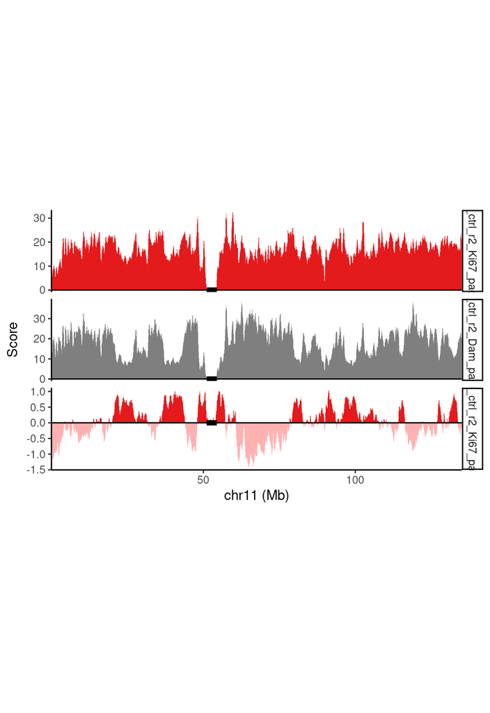

```r
#######################################
### Normalization

# pA-DamID normalization
PlotDataTracksLight(input_tib = tib_combined,
                    exp_names = c("HCT116_AID_ctrl_r2_Ki67_padamid_counts",
                                  "HCT116_AID_ctrl_r2_Dam_padamid_counts",
                                  "HCT116_AID_ctrl_r2_Ki67_padamid_norm"),
                    centromeres,
                    color_groups = c(HCT116_AID_ctrl_r2_Ki67_padamid_counts = "Ki67",
                                     HCT116_AID_ctrl_r2_Dam_padamid_counts = "Dam",
                                     HCT116_AID_ctrl_r2_Ki67_padamid_norm = "Ki67"),
                    plot_chr = "chr11",
                    smooth = 9, fix_yaxis = F, aspect_ratio = 1/5,
                    color_list = c(colors_set1[1], "grey50"))
```

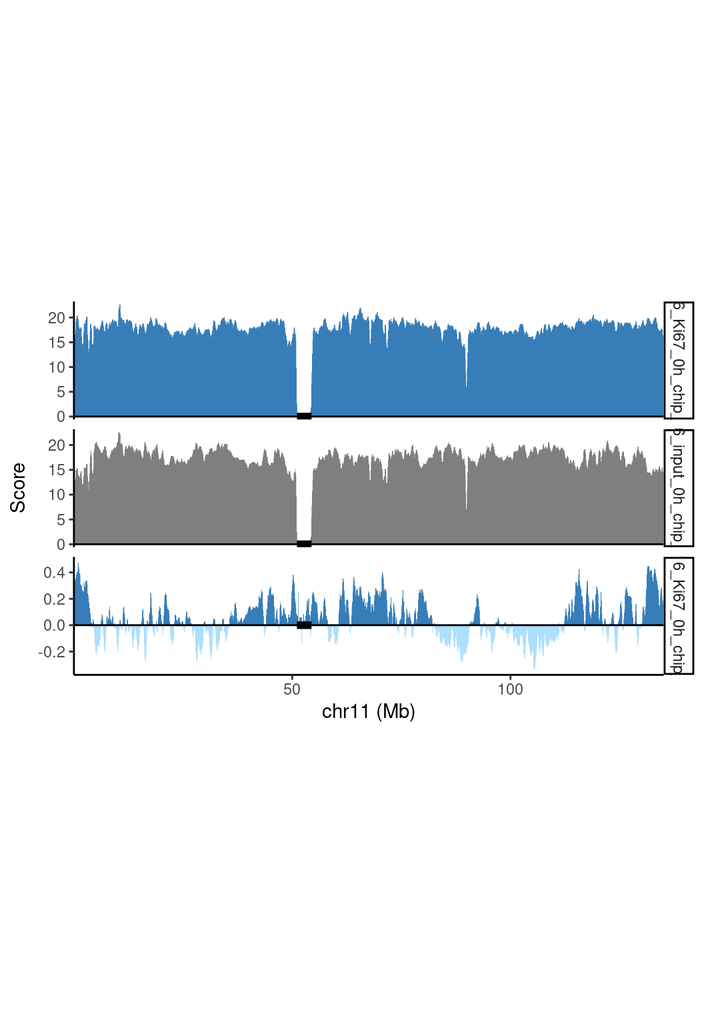

```r
# ChIP-seq normalization
PlotDataTracksLight(input_tib = tib_combined,
                    exp_names = c("HCT116_Ki67_0h_chip_counts",
                                  "HCT116_input_0h_chip_counts",
                                  "HCT116_Ki67_0h_chip_norm"),
                    centromeres,
                    color_groups = c(HCT116_Ki67_0h_chip_counts = "Ki67",
                                     HCT116_input_0h_chip_counts = "Dam",
                                     HCT116_Ki67_0h_chip_norm = "Ki67"),
                    plot_chr = "chr11",
                    smooth = 9, fix_yaxis = F, aspect_ratio = 1/5,
                    color_list = c(colors_set1[2], "grey50"))
```

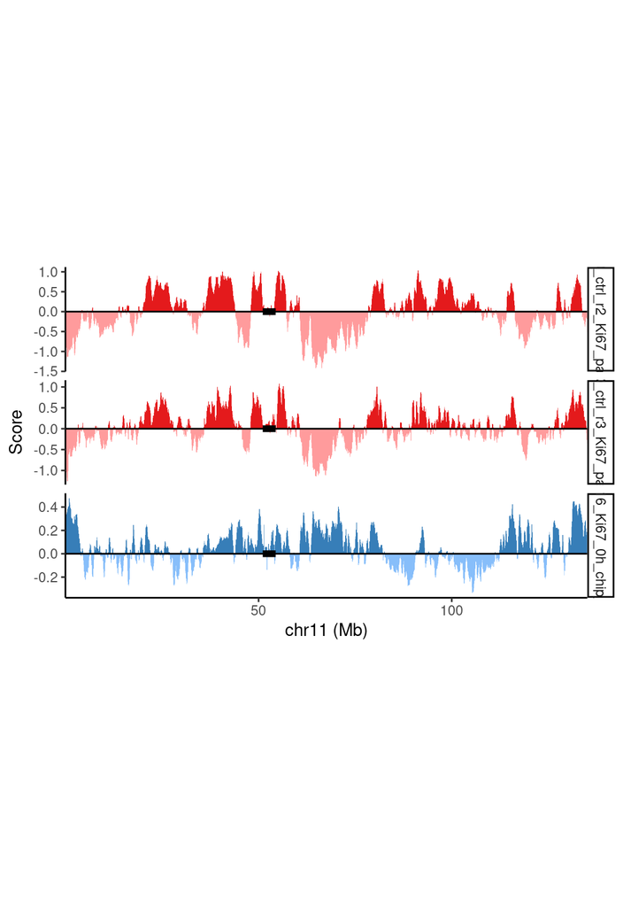

```r
#######################################
### Comparison of normalized data

# pA-DamID versus ChIP-seq
PlotDataTracksLight(input_tib = tib_combined,
                    exp_names = c("HCT116_AID_ctrl_r2_Ki67_padamid_norm",
                                  "HCT116_AID_ctrl_r3_Ki67_padamid_norm",
                                  "HCT116_Ki67_0h_chip_norm"),
                    centromeres,
                    color_groups = c(HCT116_AID_ctrl_r2_Ki67_padamid_norm = "padamid",
                                     HCT116_AID_ctrl_r3_Ki67_padamid_norm = "padamid",
                                     HCT116_Ki67_0h_chip_norm = "chip"),
                    plot_chr = "chr11",
                    smooth = 9, fix_yaxis = F, aspect_ratio = 1/5,
                    color_list = c(colors_set1[1], colors_set1[2]))
```

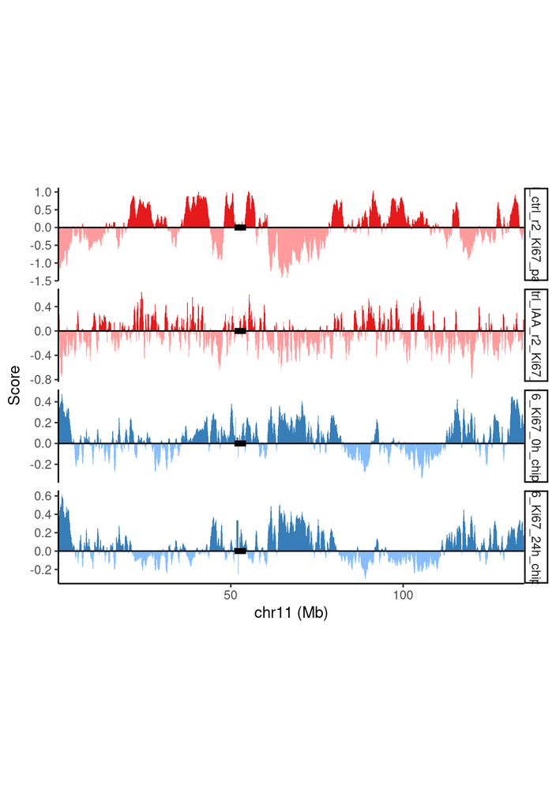

```r
# Control versus IAA
PlotDataTracksLight(input_tib = tib_combined,
                    exp_names = c("HCT116_AID_ctrl_r2_Ki67_padamid_norm",
                                  "HCT116_AID_ctrl_IAA_r2_Ki67_padamid_norm",
                                  "HCT116_Ki67_0h_chip_norm",
                                  "HCT116_Ki67_24h_chip_norm"),
                    centromeres,
                    color_groups = c(HCT116_AID_ctrl_r2_Ki67_padamid_norm = "padamid",
                                     HCT116_AID_ctrl_IAA_r2_Ki67_padamid_norm = "padamid",
                                     HCT116_Ki67_0h_chip_norm = "chip",
                                     HCT116_Ki67_24h_chip_norm = "chip"),
                    plot_chr = "chr11",
                    smooth = 9, fix_yaxis = F, aspect_ratio = 1/5,
                    color_list = c(colors_set1[1], colors_set1[2]))
```

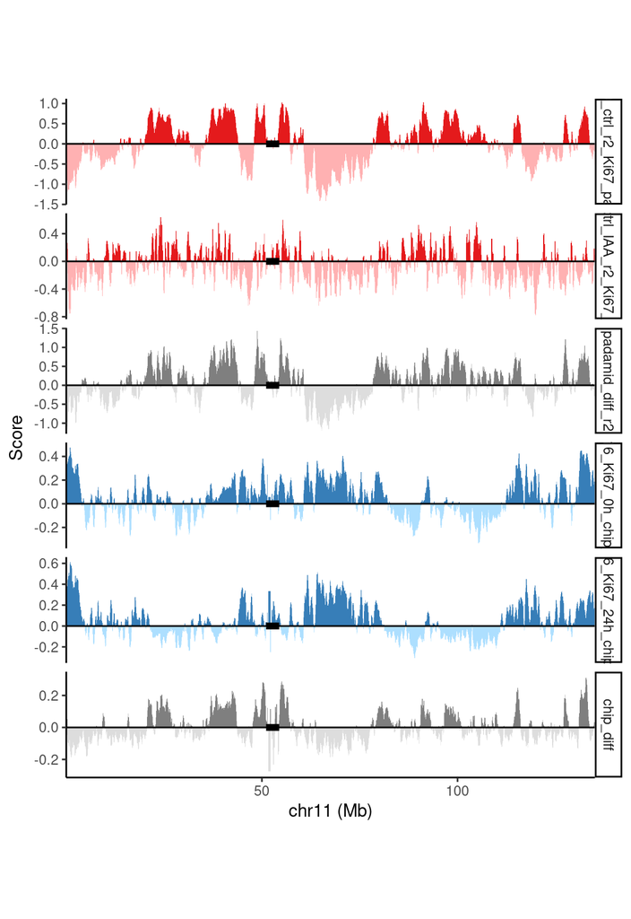

```r
# Control versus IAA - with differences
PlotDataTracksLight(input_tib = tib_combined,
                    exp_names = c("HCT116_AID_ctrl_r2_Ki67_padamid_norm",
                                  "HCT116_AID_ctrl_IAA_r2_Ki67_padamid_norm",
                                  "padamid_diff_r2",
                                  "HCT116_Ki67_0h_chip_norm",
                                  "HCT116_Ki67_24h_chip_norm",
                                  "chip_diff"),
                    centromeres,
                    color_groups = c(HCT116_AID_ctrl_r2_Ki67_padamid_norm = "padamid",
                                     HCT116_AID_ctrl_IAA_r2_Ki67_padamid_norm = "padamid",
                                     padamid_diff_r2 = "diff",
                                     HCT116_Ki67_0h_chip_norm = "chip",
                                     HCT116_Ki67_24h_chip_norm = "chip",
                                     chip_diff = "diff"),
                    plot_chr = "chr11",
                    smooth = 9, fix_yaxis = F, aspect_ratio = 1/5,
                    color_list = c(colors_set1[1], "grey50", colors_set1[2]))
```

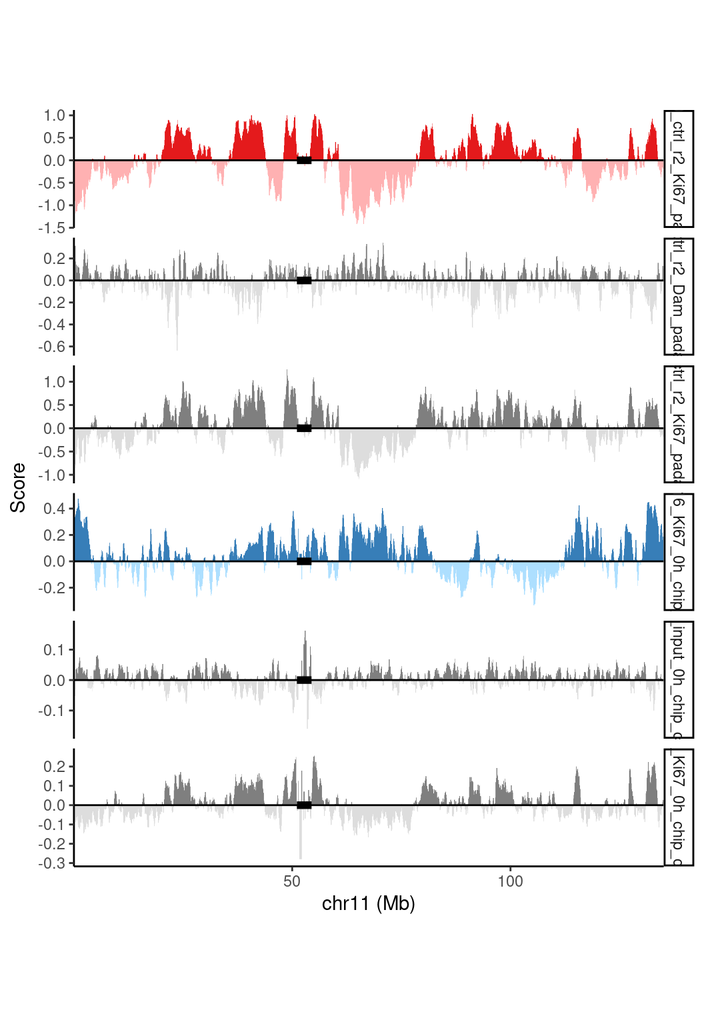

```r
#######################################
### Comparison of counts ratios

# Control versus IAA
PlotDataTracksLight(input_tib = tib_combined,
                    exp_names = c("HCT116_AID_ctrl_r2_Ki67_padamid_norm",
                                  "HCT116_AID_ctrl_r2_Dam_padamid_countsdiff",
                                  "HCT116_AID_ctrl_r2_Ki67_padamid_countsdiff",
                                  "HCT116_Ki67_0h_chip_norm",
                                  "HCT116_input_0h_chip_countsdiff",
                                  "HCT116_Ki67_0h_chip_countsdiff"),
                    centromeres,
                    color_groups = c(HCT116_AID_ctrl_r2_Ki67_padamid_norm = "padamid",
                                     HCT116_AID_ctrl_r2_Dam_padamid_countsdiff = "diff",
                                     HCT116_AID_ctrl_r2_Ki67_padamid_countsdiff = "diff",
                                     HCT116_Ki67_0h_chip_norm = "chip",
                                     HCT116_input_0h_chip_countsdiff = "diff",
                                     HCT116_Ki67_0h_chip_countsdiff = "diff"),
                    plot_chr = "chr11",
                    smooth = 9, fix_yaxis = F, aspect_ratio = 1/5,
                    color_list = c(colors_set1[1], "grey50", colors_set1[2]))
```

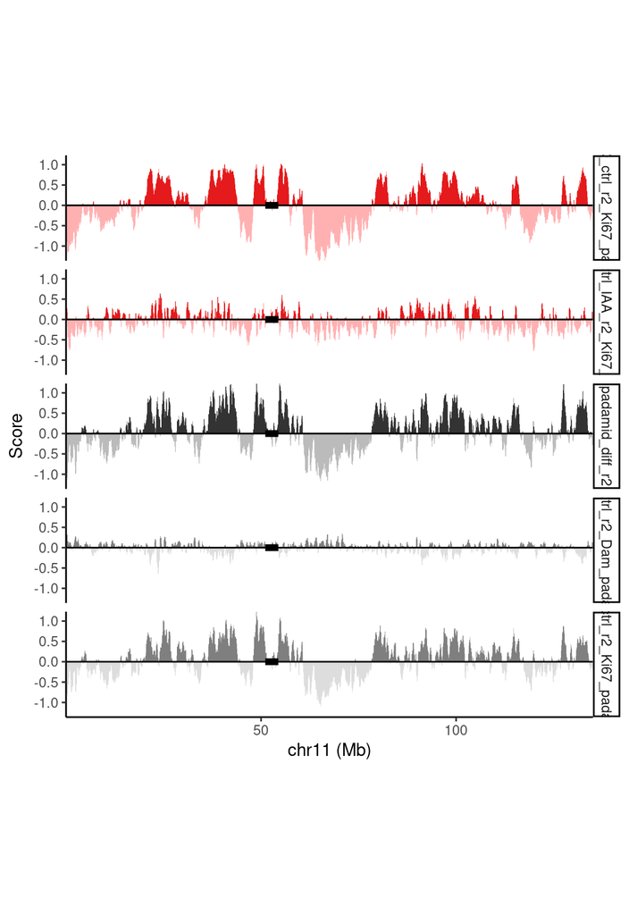

```r
#######################################
### Combined time course

# pA-DamID
PlotDataTracksLight(input_tib = tib_combined,
                    exp_names = c("HCT116_AID_ctrl_r2_Ki67_padamid_norm",
                                  "HCT116_AID_ctrl_IAA_r2_Ki67_padamid_norm",
                                  "padamid_diff_r2",
                                  "HCT116_AID_ctrl_r2_Dam_padamid_countsdiff",
                                  "HCT116_AID_ctrl_r2_Ki67_padamid_countsdiff"),
                    centromeres,
                    color_groups = c(HCT116_AID_ctrl_r2_Ki67_padamid_norm = "norm",
                                     HCT116_AID_ctrl_IAA_r2_Ki67_padamid_norm = "norm",
                                     padamid_diff_r2 = "diff_norm",
                                     HCT116_AID_ctrl_r2_Dam_padamid_countsdiff = "diff_counts",
                                     HCT116_AID_ctrl_r2_Ki67_padamid_countsdiff = "diff_counts"),
                    plot_chr = "chr11",
                    smooth = 9, fix_yaxis = T, aspect_ratio = 1/5,
                    color_list = c(colors_set1[1], "grey20", "grey50"))
```

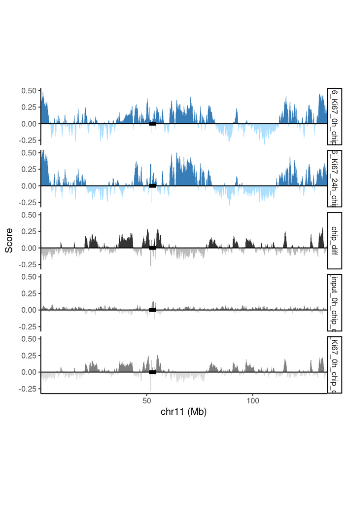

```r
# ChIP-seq
PlotDataTracksLight(input_tib = tib_combined,
                    exp_names = c("HCT116_Ki67_0h_chip_norm",
                                  "HCT116_Ki67_24h_chip_norm",
                                  "chip_diff",
                                  "HCT116_input_0h_chip_countsdiff",
                                  "HCT116_Ki67_0h_chip_countsdiff"),
                    centromeres,
                    color_groups = c(HCT116_Ki67_0h_chip_norm = "norm",
                                     HCT116_Ki67_24h_chip_norm = "norm",
                                     chip_diff = "diff_norm",
                                     HCT116_input_0h_chip_countsdiff = "diff_counts",
                                     HCT116_Ki67_0h_chip_countsdiff = "diff_counts"),
                    plot_chr = "chr11",
                    smooth = 9, fix_yaxis = T, aspect_ratio = 1/5,
                    color_list = c(colors_set1[2], "grey20", "grey50"))
```

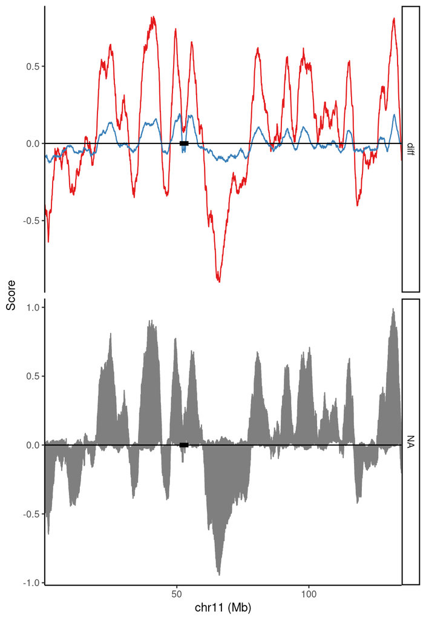

```r
# Faceted plot
PlotDataTracksLightFaceted(input_tib = tib_combined,
                           exp_names = c("padamid_diff",
                                         "chip_diff"),
                           centromeres,
                           color_groups = c(padamid_diff = "padamid",
                                            chip_diff = "chip"),
                           plot_chr = "chr11",
                           facet_groups = c(padamid_diff = "diff",
                                            chip_diff = "diff"),
                           smooth = 51, fix_yaxis = F,
                           color_list = c(colors_set1[c(1, 2)]))
```

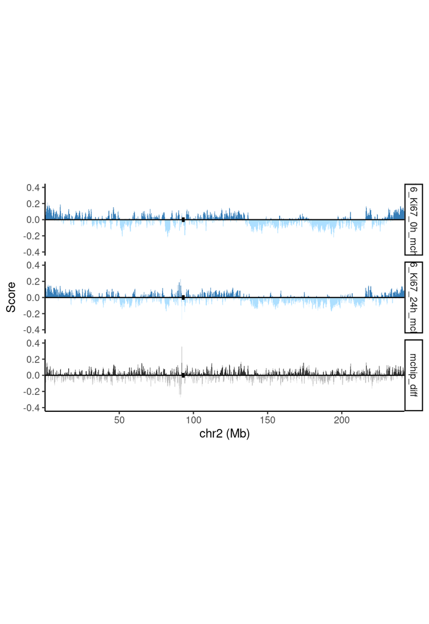

```r
#######################################
### Mitotic data

# mitotic ChIP-seq
PlotDataTracksLight(input_tib = tib_combined,
                    exp_names = c("mHCT116_Ki67_0h_mchip_norm",
                                  "mHCT116_Ki67_24h_mchip_norm",
                                  "mchip_diff"),
                    centromeres,
                    color_groups = c(mHCT116_Ki67_0h_mchip_norm = "norm",
                                     mHCT116_Ki67_24h_mchip_norm = "norm",
                                     mchip_diff = "diff_norm"),
                    plot_chr = "chr2", ylimits = c(-0.4, 0.4),
                    smooth = 9, fix_yaxis = T, aspect_ratio = 1/5,
                    color_list = c(colors_set1[2], "grey20"))
```

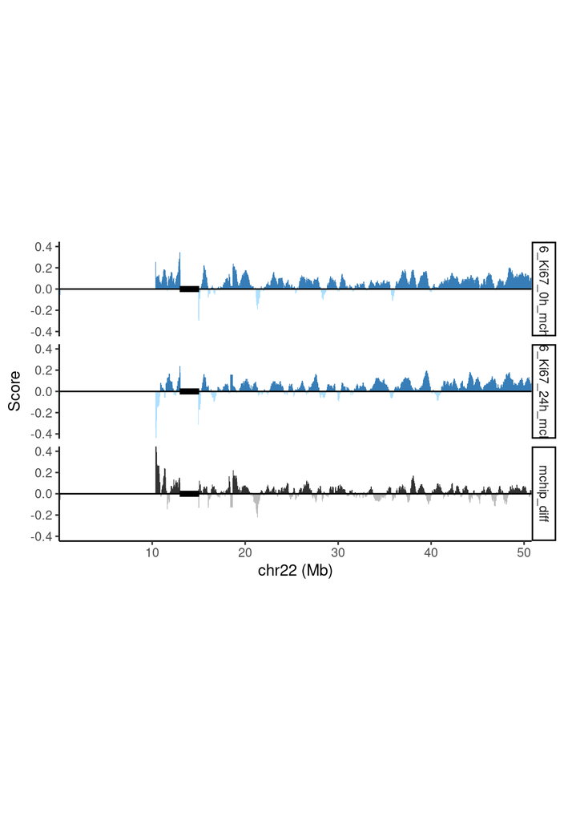

```r
PlotDataTracksLight(input_tib = tib_combined,
                    exp_names = c("mHCT116_Ki67_0h_mchip_norm",
                                  "mHCT116_Ki67_24h_mchip_norm",
                                  "mchip_diff"),
                    centromeres,
                    color_groups = c(mHCT116_Ki67_0h_mchip_norm = "norm",
                                     mHCT116_Ki67_24h_mchip_norm = "norm",
                                     mchip_diff = "diff_norm"),
                    plot_chr = "chr22", ylimits = c(-0.4, 0.4),
                    smooth = 9, fix_yaxis = T, aspect_ratio = 1/5,
                    color_list = c(colors_set1[2], "grey20"))
```

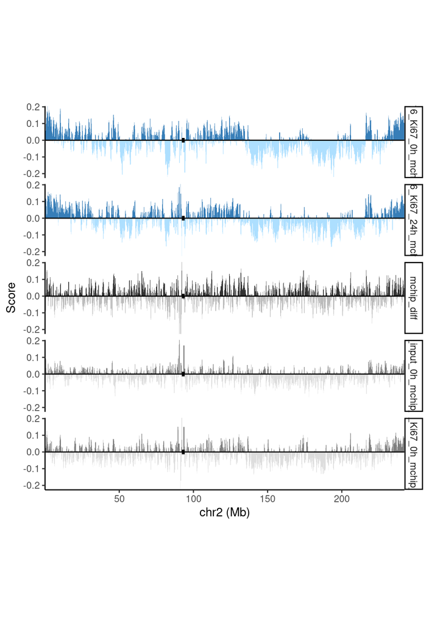

```r
# mitotic ChIP-seq with individual ratios
PlotDataTracksLight(input_tib = tib_combined,
                    exp_names = c("mHCT116_Ki67_0h_mchip_norm",
                                  "mHCT116_Ki67_24h_mchip_norm",
                                  "mchip_diff",
                                  "mHCT116_input_0h_mchip_countsdiff",
                                  "mHCT116_Ki67_0h_mchip_countsdiff"),
                    centromeres,
                    color_groups = c(mHCT116_Ki67_0h_mchip_norm = "norm",
                                     mHCT116_Ki67_24h_mchip_norm = "norm",
                                     mchip_diff = "diff_norm",
                                     mHCT116_input_0h_mchip_countsdiff = "diff_counts",
                                     mHCT116_Ki67_0h_mchip_countsdiff = "diff_counts"),
                    plot_chr = "chr2",
                    smooth = 9, fix_yaxis = T, aspect_ratio = 1/5,
                    color_list = c(colors_set1[2], "grey20", "grey50"))
```

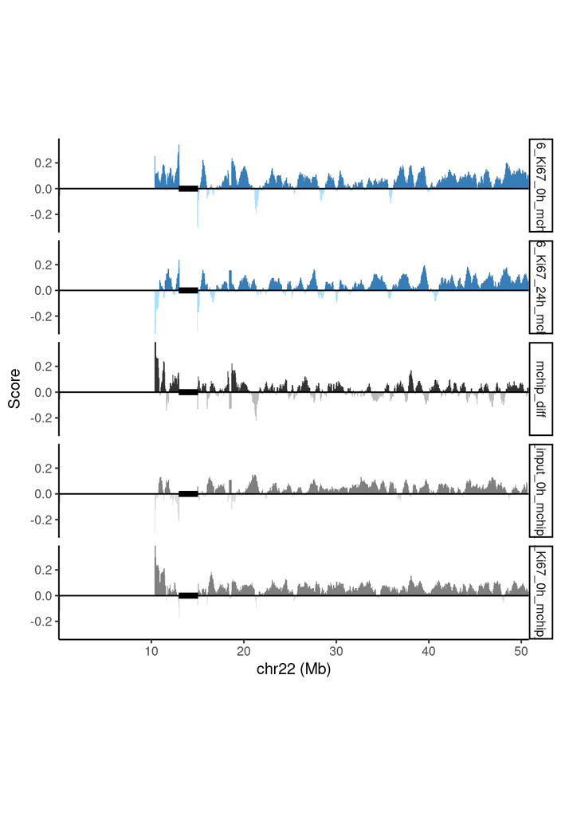

```r
PlotDataTracksLight(input_tib = tib_combined,
                    exp_names = c("mHCT116_Ki67_0h_mchip_norm",
                                  "mHCT116_Ki67_24h_mchip_norm",
                                  "mchip_diff",
                                  "mHCT116_input_0h_mchip_countsdiff",
                                  "mHCT116_Ki67_0h_mchip_countsdiff"),
                    centromeres,
                    color_groups = c(mHCT116_Ki67_0h_mchip_norm = "norm",
                                     mHCT116_Ki67_24h_mchip_norm = "norm",
                                     mchip_diff = "diff_norm",
                                     mHCT116_input_0h_mchip_countsdiff = "diff_counts",
                                     mHCT116_Ki67_0h_mchip_countsdiff = "diff_counts"),
                    plot_chr = "chr22",
                    smooth = 9, fix_yaxis = T, aspect_ratio = 1/5,
                    color_list = c(colors_set1[2], "grey20", "grey50"))
```

### 4. Scatter plots

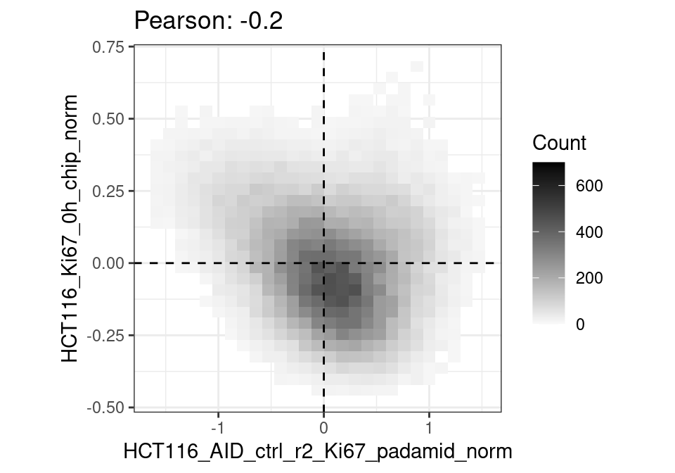

```r
# Make scatter plots between pA-DamID and ChIP-seq
PlotScatterBinned(tib_combined,
                  n1 = "HCT116_AID_ctrl_r2_Ki67_padamid_norm",
                  n2 = "HCT116_Ki67_0h_chip_norm",
                  count_range = c(0, 700))
```

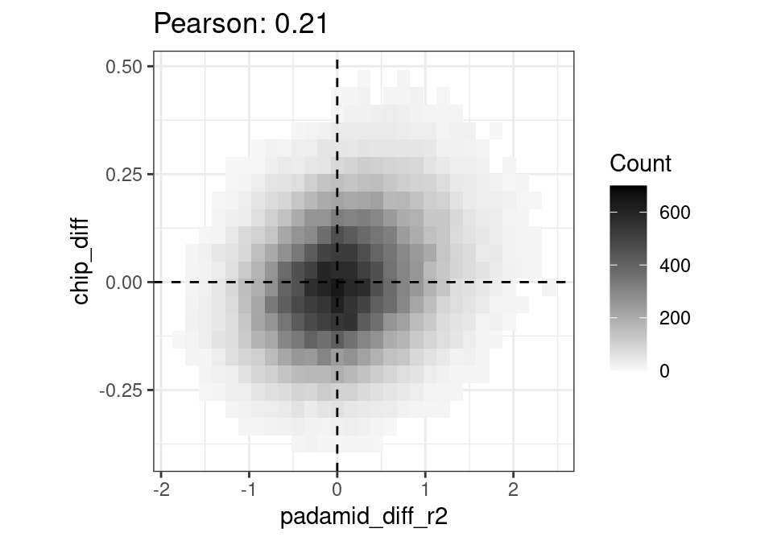

```r
PlotScatterBinned(tib_combined,
                  n1 = "padamid_diff_r2",
                  n2 = "chip_diff",
                  count_range = c(0, 700))
```

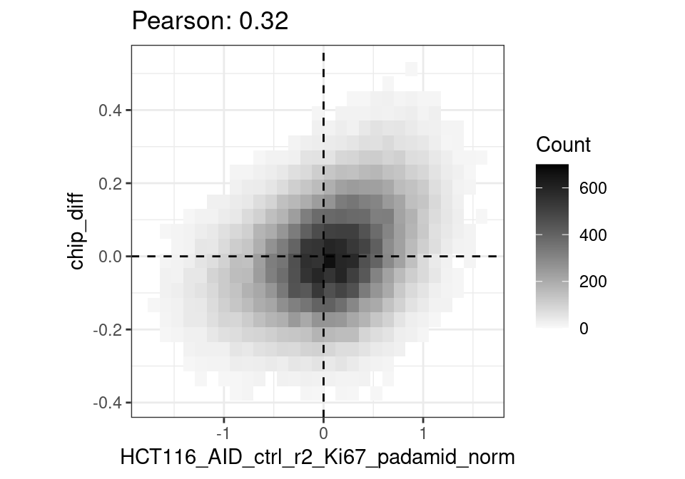

```r
PlotScatterBinned(tib_combined,
                  n1 = "HCT116_AID_ctrl_r2_Ki67_padamid_norm",
                  n2 = "chip_diff",
                  count_range = c(0, 700))
```

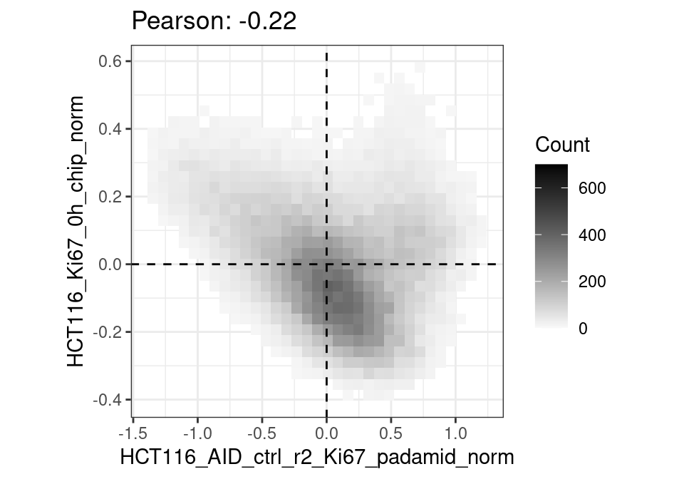

```r
# Repeat, but with smoothing to account for noisy data
tib_combined_smooth <- tib_combined %>%
  dplyr::mutate_at(vars(contains("HCT116")), function(x) runmean(x, k = 3))

PlotScatterBinned(tib_combined_smooth,
                  n1 = "HCT116_AID_ctrl_r2_Ki67_padamid_norm",
                  n2 = "HCT116_Ki67_0h_chip_norm",
                  count_range = c(0, 700))
```

[figure not shown]

```r
PlotScatterBinned(tib_combined_smooth,
                  n1 = "padamid_diff_r2",
                  n2 = "chip_diff",
                  count_range = c(0, 700))
```

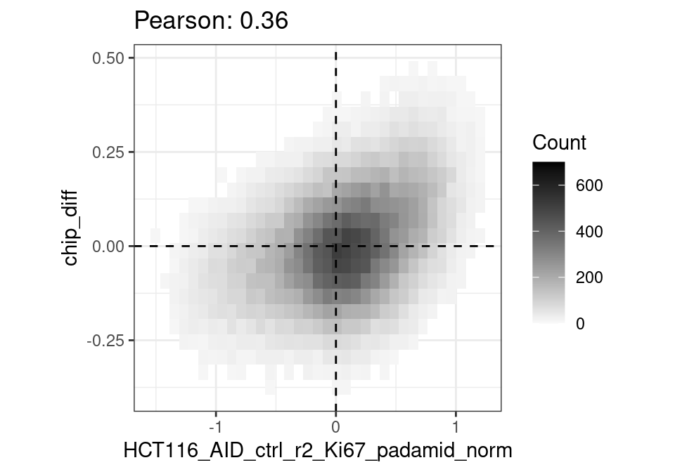

```r
PlotScatterBinned(tib_combined_smooth,
                  n1 = "HCT116_AID_ctrl_r2_Ki67_padamid_norm",
                  n2 = "chip_diff",
                  count_range = c(0, 700))
```

### 5. Distance to telomere plots for the mitotic data

Make the same plots as for the pA-DamID data: for every chromosome, plot the scores in a smooth line from the telomere

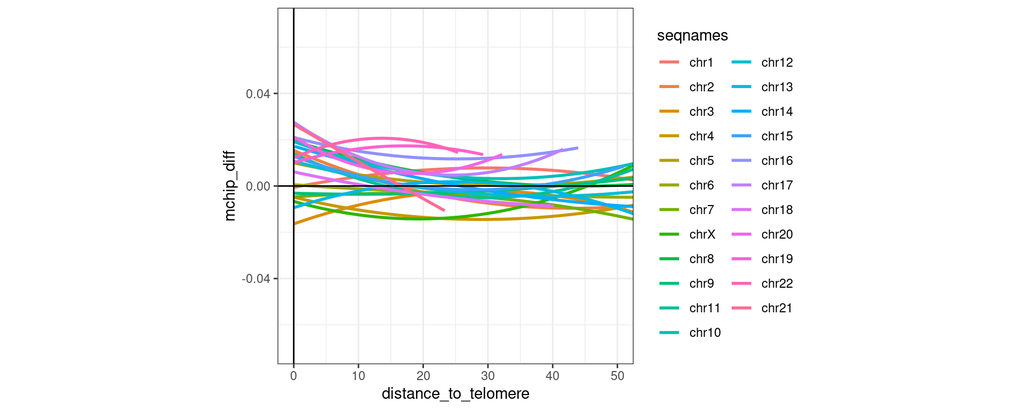

```r
# Calculate distance to telomere
# Also, prepare telomeres
telomeres <- c(GRanges(seqnames = chromosomes,
                       ranges = IRanges(start = 1, end = 1)),
               GRanges(seqnames = chromosomes,
                       ranges = IRanges(start = seqlengths(gr_padamid_combined)[chromosomes],
                                        end = seqlengths(gr_padamid_combined)[chromosomes])))
seqinfo(telomeres) <- seqinfo(gr_padamid_combined)
telomeres <- sort(telomeres)

# Remove chrY
tib_combined <- tib_combined[tib_combined$seqnames %in% chromosomes, ]
dis <- distanceToNearest(as(tib_combined, "GRanges"), telomeres)
tib_combined$distance_to_telomere <- mcols(dis)$distance / 1e6

# Prepare smooth line of all telomere distances separately
tib_combined %>%
  dplyr::select(seqnames, distance_to_telomere, mchip_diff) %>%
  drop_na() %>%
  filter(distance_to_telomere < 55) %>%
  mutate(seqnames = factor(seqnames, chrom_sizes$seqnames)) %>%
  ggplot(aes(x = distance_to_telomere, y = mchip_diff, col = seqnames)) +
  geom_smooth(method = "loess", se = F, span = 10) +
  geom_vline(xintercept = 0) +
  #geom_vline(xintercept = 25, linetype = "dashed") +
  geom_hline(yintercept = 0) +
  coord_cartesian(xlim = c(0, 50),
                  ylim = c(-0.07, 0.07)) +
  theme_bw() +
  theme(aspect.ratio = 1)
```